# Lab_2

```python
# import libraries
import pandas as pd
import numpy as np
from sklearn import datasets
import matplotlib.pyplot as plt
import seaborn as sns
from sklearn.preprocessing import PolynomialFeatures
from sklearn.linear_model import LinearRegression
from sklearn.pipeline import make_pipeline
from sklearn.model_selection import train_test_split
from sklearn.metrics import r2_score, mean_absolute_error, mean_squared_error
from sklearn.preprocessing import StandardScaler
from sklearn.tree import DecisionTreeRegressor
from sklearn.neighbors import KNeighborsRegressor
```

### **1.** Get the data.

```python
# Load the diabetes dataset
diabetes_data = datasets.load_diabetes()

# Create a DataFrame from the 'data'
df = pd.DataFrame(diabetes_data['data'], columns=diabetes_data['feature_names'])
# Add a column with the target
df['target'] = diabetes_data['target']
# Standardize the features
scaler = StandardScaler()
scaled_features = scaler.fit_transform(df)
# Convert back to DataFrame for better readability
scaled_df = pd.DataFrame(scaled_features, columns=df.columns)
```

```python
diabetes_data=scaled_df.copy()
diabetes_data.head()
```

|  | age | sex | bmi | bp | s1 | s2 | s3 | s4 | s5 | s6 | target |
| --- | --- | --- | --- | --- | --- | --- | --- | --- | --- | --- | --- |
| 0 | 0.800500 | 1.065488 | 1.297088 | 0.459841 | -0.929746 | -0.732065 | -0.912451 | -0.054499 | 0.418531 | -0.370989 | -0.014719 |
| 1 | -0.039567 | -0.938537 | -1.082180 | -0.553505 | -0.177624 | -0.402886 | 1.564414 | -0.830301 | -1.436589 | -1.938479 | -1.001659 |
| 2 | 1.793307 | 1.065488 | 0.934533 | -0.119214 | -0.958674 | -0.718897 | -0.680245 | -0.054499 | 0.060156 | -0.545154 | -0.144580 |
| 3 | -1.872441 | -0.938537 | -0.243771 | -0.770650 | 0.256292 | 0.525397 | -0.757647 | 0.721302 | 0.476983 | -0.196823 | 0.699513 |
| 4 | 0.113172 | -0.938537 | -0.764944 | 0.459841 | 0.082726 | 0.327890 | 0.171178 | -0.054499 | -0.672502 | -0.980568 | -0.222496 |

### **3.** EDA - Describe the data, explore it, and provide insights about it. This should include at least: statistics, scatter plots histograms, a correlation matrix, and concise and relevant insights

```python
diabetes_data.describe()
```

|  | age | sex | bmi | bp | s1 | s2 | s3 | s4 | s5 | s6 | target |
| --- | --- | --- | --- | --- | --- | --- | --- | --- | --- | --- | --- |
| count | 4.420000e+02 | 4.420000e+02 | 4.420000e+02 | 4.420000e+02 | 4.420000e+02 | 442.000000 | 442.000000 | 4.420000e+02 | 4.420000e+02 | 4.420000e+02 | 4.420000e+02 |
| mean | 8.037814e-18 | 1.607563e-17 | -2.813235e-17 | -1.607563e-17 | -8.037814e-18 | 0.000000 | 0.000000 | 1.607563e-17 | -8.037814e-18 | -1.607563e-17 | -1.687941e-16 |
| std | 1.001133e+00 | 1.001133e+00 | 1.001133e+00 | 1.001133e+00 | 1.001133e+00 | 1.001133 | 1.001133 | 1.001133e+00 | 1.001133e+00 | 1.001133e+00 | 1.001133e+00 |
| min | -2.254290e+00 | -9.385367e-01 | -1.897929e+00 | -2.363050e+00 | -2.665411e+00 | -2.430626 | -2.150883 | -1.606102e+00 | -2.651040e+00 | -2.896390e+00 | -1.650961e+00 |
| 25% | -7.841722e-01 | -9.385367e-01 | -7.196249e-01 | -7.706500e-01 | -7.200196e-01 | -0.638249 | -0.738296 | -8.303008e-01 | -6.989486e-01 | -6.975491e-01 | -8.458263e-01 |
| 50% | 1.131724e-01 | -9.385367e-01 | -1.531324e-01 | -1.192138e-01 | -9.084100e-02 | -0.080291 | -0.138431 | -5.449919e-02 | -4.093693e-02 | -2.265729e-02 | -1.510729e-01 |
| 75% | 8.005001e-01 | 1.065488e+00 | 6.569519e-01 | 7.493678e-01 | 5.961931e-01 | 0.627442 | 0.616239 | 7.213025e-01 | 6.818506e-01 | 5.869224e-01 | 7.709362e-01 |
| max | 2.327895e+00 | 1.065488e+00 | 3.585718e+00 | 2.776058e+00 | 3.235851e+00 | 4.179278 | 3.809072 | 3.894331e+00 | 2.808722e+00 | 2.851075e+00 | 2.517559e+00 |

```
array([[<Axes: title={'center': 'age'}>, <Axes: title={'center': 'sex'}>,
        <Axes: title={'center': 'bmi'}>],
       [<Axes: title={'center': 'bp'}>, <Axes: title={'center': 's1'}>,
        <Axes: title={'center': 's2'}>],
       [<Axes: title={'center': 's3'}>, <Axes: title={'center': 's4'}>,
        <Axes: title={'center': 's5'}>],
       [<Axes: title={'center': 's6'}>,
        <Axes: title={'center': 'target'}>, <Axes: >]], dtype=object)
```

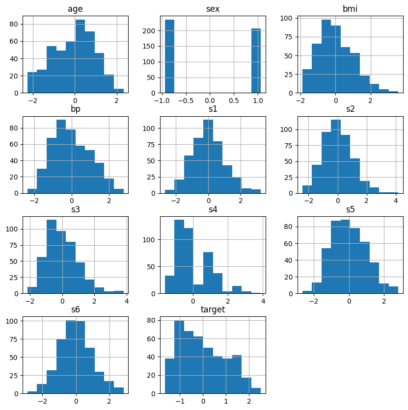

```python
diabetes_data.hist(figsize=(10, 10))
```

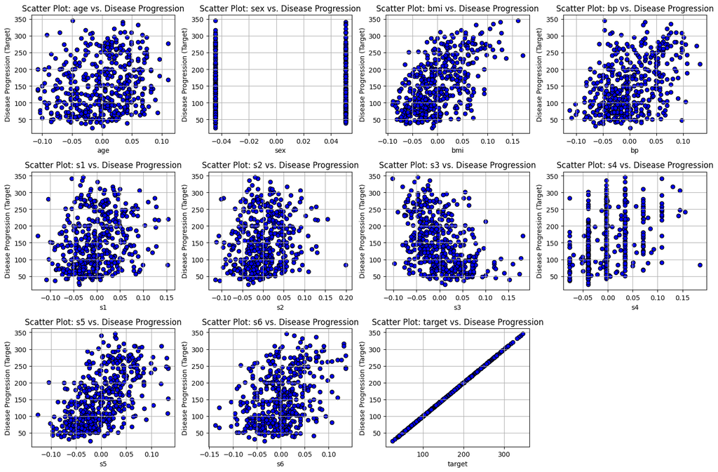

```python
plt.figure(figsize=(15, 10))

# Loop through each feature to create subplots
for i, column in enumerate(diabetes_data.columns):
    plt.subplot(3, 4, i + 1)  # 3 rows, 4 columns of subplots
    plt.scatter(df[column], df['target'], color='blue', edgecolor='k')
    plt.title(f'Scatter Plot: {column} vs. Disease Progression')
    plt.xlabel(column)
    plt.ylabel('Disease Progression (Target)')
    plt.grid(True)

# Adjust layout for better spacing
plt.tight_layout()
plt.show()
```

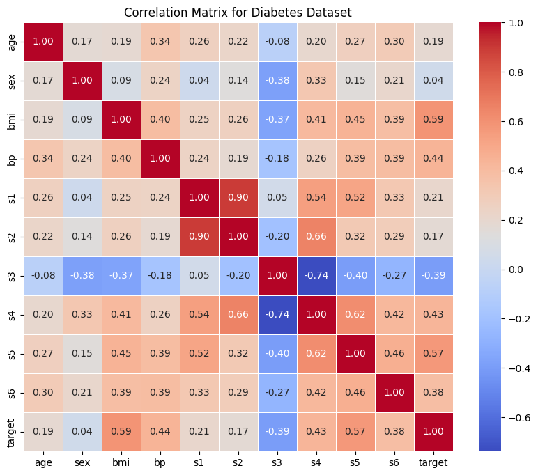

```python
# Calculate the correlation matrix
correlation_matrix = diabetes_data.corr()
# Visualize the correlation matrix using a heatmap
plt.figure(figsize=(10, 8))
sns.heatmap(correlation_matrix, annot=True, fmt=".2f", cmap='coolwarm', square=True, linewidths=0.5)

# Add titles and labels
plt.title('Correlation Matrix for Diabetes Dataset')
plt.show()
```

```python
# Example of interpreting the heatmap
correlation_matrix = diabetes_data.corr()

# Find pairs of highly correlated features
high_corr_pairs = [(i, j) for i in correlation_matrix.columns for j in correlation_matrix.columns if i != j and abs(correlation_matrix.loc[i, j]) > 0.8]

print("Highly correlated pairs:", high_corr_pairs)
```

```
Highly correlated pairs: [('s1', 's2'), ('s2', 's1')]
```

### **Correlation with Target Variable:**

```python
# drop s2 from the dataset as it hase low correlation with the target

diabetes_data.drop(columns=['s2'], inplace=True)
```

### **4.** Clean the data if needed, and explain your reasoning for your reader

```python
# Clean the data if needed, and explain your reasoning for your reader (1 point)
# Check for missing values in the dataframe
diabetes_data.isnull().sum()
```

```
age       0
sex       0
bmi       0
bp        0
s1        0
s3        0
s4        0
s5        0
s6        0
target    0
dtype: int64
```

```python
# Create the features and target DataFrames as X and y
X=diabetes_data[['bmi']]
y=diabetes_data[['target']]

X.shape, y.shape
```

```
((442, 1), (442, 1))
```

### **5. Data Split**

#### **Train 75%** - Use to train model

#### **Validation 10%** - validate the model on this , pred

#### **Test 15%** - apply the model on this, test

```python
# First, split the data into training + validation (90%) and test set (10%)
X_train_val, X_test, y_train_val, y_test = train_test_split(X, y, test_size=0.15, random_state=42)

# Now, split the training + validation set into training (75%) and validation set (10%)
X_train, X_val, y_train, y_val = train_test_split(X_train_val, y_train_val, test_size=0.12, random_state=42)

# Print the sizes of the splits to verify
print(f"Training set size: {X_train.shape[0]} samples")
print(f"Validation set size: {X_val.shape[0]} samples")
print(f"Test set size: {X_test.shape[0]} samples")
```

```
Training set size: 330 samples
Validation set size: 45 samples
Test set size: 67 samples
```

### **6.** Models: a univariate polynomial regression on the BMI feature versus the "disease progression one year after baseline" - from degree 0 to 5

```python
#Compare the models using the training and validation data. Construct a table summarizing the train validation results. Each model should have a separate row in the table (3 points):
#- R-Squared
#- Mean Absolute Error (MAE)
#- MAPE
results = []
def polynomial_fit(X, y, degree, X_val=None, y_val=None):
    model = LinearRegression()

    if degree != 0:  # Linear Regression
        poly_features = PolynomialFeatures(degree=degree, include_bias=False)
    else:
        poly_features = PolynomialFeatures(degree=degree, include_bias=True)

    X_train_poly = poly_features.fit_transform(X)
    model.fit(X_train_poly, y)
    X_val_poly = poly_features.transform(X_val)

    y_val_pred = model.predict(X_val_poly)

    mape = np.mean(np.abs((y_val - y_val_pred) / y_val)) * 100
    r2 = r2_score(y_val, y_val_pred)
    mae = mean_absolute_error(y_val, y_val_pred)
    results.append((degree, r2, mae, mape))

    return model
```

### **7.** Compare the models using the training and validation data. Construct a table summarizing the train validation results. Each model should have a separate row in the table (3 points):

- R-Squared -Mean Absolute Error (MAE) -MAPE

```python
models = []
results = []
for degree in range(0,6):
    models.append(polynomial_fit(X=X_train, y=y_train, degree=degree, X_val=X_val, y_val=y_val))
data = pd.DataFrame(results, columns=['Degree', 'R-Squared', 'MAE' , 'MAPE'])
print(data)
```

```
   Degree  R-Squared       MAE        MAPE
0       0  -0.000011  0.823932  100.048381
1       1   0.449292  0.545382  101.998570
2       2   0.449158  0.542267  101.072914
3       3   0.447291  0.542051  101.600198
4       4   0.449064  0.544801  103.452870
5       5   0.453513  0.546497  103.898565
```

### **8.** Identify the best

```python
# Identify the best model based on the table above.

# Identify the best model based on R2 (maximum R2 value)
best_model_r2 = data.loc[data['R-Squared'].idxmax()]
print("Best Model Based on R2:")
print(best_model_r2)

# Identify the best model based on MAE (minimum MAE value)
best_model_mae = data.loc[data['MAE'].idxmin()]
print("\nBest Model Based on MAE:")
print(best_model_mae)

# Identify the best model based on MAPE (minimum MAPE value)
best_model_mape = data.loc[data['MAPE'].idxmin()]
print("\nBest Model Based on MAPE:")
print(best_model_mape)
```

```
Best Model Based on R2:
Degree         5.000000
R-Squared      0.453513
MAE            0.546497
MAPE         103.898565
Name: 5, dtype: float64

Best Model Based on MAE:
Degree         3.000000
R-Squared      0.447291
MAE            0.542051
MAPE         101.600198
Name: 3, dtype: float64

Best Model Based on MAPE:
Degree         0.000000
R-Squared     -0.000011
MAE            0.823932
MAPE         100.048381
Name: 0, dtype: float64
```

### **Model Selection**: Model 3 will be consider as the best model, since it has has lowest MAE comapre to the rest models, and this make it more reliable in predicting closer value to true target,

### **9.** Run the chosen model on the test set and provide results (R-Squared, MAPE, MAE)

```python
#Run the chosen model on the test set and provide results (R-Squared, MAPE, MAE) (1 point).
# Run the best model on the test set and provide the results. Explain the results to your reader.
poly_features = PolynomialFeatures(degree=3, include_bias=False)
X_train_poly = poly_features.fit_transform(X_train)
y_test_pred=models[3].predict(poly_features.transform(X_test))
mape = np.mean(np.abs((y_test - y_test_pred) / y_test)) * 100
r2 = r2_score(y_test, y_test_pred)
mae = mean_absolute_error(y_test, y_test_pred)
print(f"R-Squared: {r2:.4f}")
print(f"Mean Absolute Error: {mae:.4f}")
print(f"Mean Absolute Percentage Error: {mape:.4f}")
```

```
R-Squared: 0.2069
Mean Absolute Error: 0.7094
Mean Absolute Percentage Error: 221.7090
```

### **MAPE** on the other hand is 221.71% highlights significant issues with percentage-based accuracy, where the model’s predictions deviate from the true values by more than twice the actual value